# Predicting if Glass is from a Building

Ainsley Carlson

2025-11-30

## 1 Introduction

Observations in the dataset come from 214 pieces of glass collected to predict if they are a type of float glass or not based on the makeup of different elements and their reflextive index. Prediction ability would help aid in criminal investigations as the glass can be used as evidence if correctly identified.

### 1.1 Variable Description

RI [Numeric]: refractive index

Na [Numeric]: Sodium weight percent in corresponding oxide

Mg [Numeric]: Magnesium weight percent in corresponding oxide

Al [Numeric]: Aluminum weight percent in corresponding oxide

Si [Numeric]: Silicon weight percent in corresponding oxide

K [Numeric]: Potassium weight percent in corresponding oxide

Ca [Numeric]: Calcium weight percent in corresponding oxide

Ba [Numeric]: Barium weight percent in corresponding oxide

Fe [Numeric]: Iron weight percent in corresponding oxide

Type [Categorical]: Glass type where type=1 & type=2 are building windows, type=3, & type=4 are vehicle windows, type=5 is containers, type=6 is tableware, and type=7 is headlamps.

Building [binary]: If the glass comes from a building or not, used for binary prediction variable.

*Data Source: https://archive.ics.uci.edu/dataset/42/glass+identification*

## 2 Exploratory Data Analysis

### 2.1 Variable Summaries

```r
sum(is.na(glass))
```

```
[1] 0
```

```r
summary(glass)
```

```
       RI              Na              Mg              Al
 Min.   :1.511   Min.   :10.73   Min.   :0.000   Min.   :0.290
 1st Qu.:1.517   1st Qu.:12.91   1st Qu.:2.115   1st Qu.:1.190
 Median :1.518   Median :13.30   Median :3.480   Median :1.360
 Mean   :1.518   Mean   :13.41   Mean   :2.685   Mean   :1.445
 3rd Qu.:1.519   3rd Qu.:13.82   3rd Qu.:3.600   3rd Qu.:1.630
 Max.   :1.534   Max.   :17.38   Max.   :4.490   Max.   :3.500
       Si              K                Ca               Ba
 Min.   :69.81   Min.   :0.0000   Min.   : 5.430   Min.   :0.000
 1st Qu.:72.28   1st Qu.:0.1225   1st Qu.: 8.240   1st Qu.:0.000
 Median :72.79   Median :0.5550   Median : 8.600   Median :0.000
 Mean   :72.65   Mean   :0.4971   Mean   : 8.957   Mean   :0.175
 3rd Qu.:73.09   3rd Qu.:0.6100   3rd Qu.: 9.172   3rd Qu.:0.000
 Max.   :75.41   Max.   :6.2100   Max.   :16.190   Max.   :3.150
       Fe               Type        building
 Min.   :0.00000   Min.   :1.00   Length:214
 1st Qu.:0.00000   1st Qu.:1.00   Class :character
 Median :0.00000   Median :2.00   Mode  :character
 Mean   :0.05701   Mean   :2.78
 3rd Qu.:0.10000   3rd Qu.:3.00
 Max.   :0.51000   Max.   :7.00
```

```r
mat_glass<-cor(glass[,-(10:11)])
round(mat_glass, 4)
```

```
        RI      Na      Mg      Al      Si       K      Ca      Ba      Fe
RI  1.0000 -0.1919 -0.1223 -0.4073 -0.5421 -0.2898  0.8104 -0.0004  0.1430
Na -0.1919  1.0000 -0.2737  0.1568 -0.0698 -0.2661 -0.2754  0.3266 -0.2413
Mg -0.1223 -0.2737  1.0000 -0.4818 -0.1659  0.0054 -0.4438 -0.4923  0.0831
Al -0.4073  0.1568 -0.4818  1.0000 -0.0055  0.3260 -0.2596  0.4794 -0.0744
Si -0.5421 -0.0698 -0.1659 -0.0055  1.0000 -0.1933 -0.2087 -0.1022 -0.0942
K  -0.2898 -0.2661  0.0054  0.3260 -0.1933  1.0000 -0.3178 -0.0426 -0.0077
Ca  0.8104 -0.2754 -0.4438 -0.2596 -0.2087 -0.3178  1.0000 -0.1128  0.1250
Ba -0.0004  0.3266 -0.4923  0.4794 -0.1022 -0.0426 -0.1128  1.0000 -0.0587
Fe  0.1430 -0.2413  0.0831 -0.0744 -0.0942 -0.0077  0.1250 -0.0587  1.0000
```

There are no missing values in this data and all variables appear to have plausible values, so no feature engineering will be needed for this data analysis. Looking at the correlation matrix between the feture variables shows that the reflection index is highly correlated with calcium and moderately correlated with silicon. Approximately 68.22% of the glass types were from buildings .

### 2.2 Distribution of Variables

```r
p1<-glass %>%
  ggplot(aes(x = RI)) +
  geom_density(alpha=0.6, fill="#785EF0", color="#785EF0") +
  labs(title="Refractive Index", x="Score", y="Density")  +
  theme_minimal() +
   theme(legend.position='none', axis.text.x = element_text(angle=0, vjust=.7, hjust=0.8))



p2<-glass %>%
  ggplot(aes(x = Na)) +
  geom_density(alpha=0.6, fill="#DC267F", color="#DC267F") +
  labs(title="Sodium Weight Percent", x="Percent", y="Density")  +
  theme_minimal() +
   theme(legend.position='none', axis.text.x = element_text(angle=0, vjust=.7, hjust=0.8))

p3<-glass %>%
  ggplot(aes(x = Mg)) +
  geom_density(alpha=0.6,  fill="#648FFF", color="#648FFF") +
  labs(title="Magnesium Weight Percent", x="Percent", y="Density")  +
  theme_minimal() +
   theme(legend.position='none', axis.text.x = element_text(angle=0, vjust=.7, hjust=0.8))

p4<-glass %>%
  ggplot(aes(x = Al)) +
  geom_density(alpha=0.6, fill="#DC267F", color="#DC267F") +
  labs(title="Aluminum Weight Percent", x="Percent", y="Density")  +
  theme_minimal() +
   theme(legend.position='none', axis.text.x = element_text(angle=0, vjust=.7, hjust=0.8))



p5<-glass %>%
  ggplot(aes(x = Si)) +
  geom_density(alpha=0.6, fill="#648FFF", color="#648FFF") +
  labs(title="Silicon Weight Percent", x="Percent", y="Density")  +
  theme_minimal() +
   theme(legend.position='none', axis.text.x = element_text(angle=0, vjust=.7, hjust=0.8))

p6<-glass %>%
  ggplot(aes(x = K)) +
  geom_density(alpha=0.6,  fill="#785EF0", color="#785EF0") +
  labs(title="Potassium Weight Percent", x="Percent", y="Density")  +
  theme_minimal() +
   theme(legend.position='none', axis.text.x = element_text(angle=0, vjust=.7, hjust=0.8))


p7<-glass %>%
  ggplot(aes(x = Ca)) +
  geom_density(alpha=0.6, fill="#648FFF", color="#648FFF") +
  labs(title="Calcium Weight Percent", x="Percent", y="Density")  +
  theme_minimal() +
   theme(legend.position='none', axis.text.x = element_text(angle=0, vjust=.7, hjust=0.8))



p8<-glass %>%
  ggplot(aes(x = Ba)) +
  geom_density(alpha=0.6, fill="#785EF0", color="#785EF0") +
  labs(title="Barium Weight Percent", x="Percent", y="Count")  +
  theme_minimal() +
   theme(legend.position='none', axis.text.x = element_text(angle=0, vjust=.7, hjust=0.8))

p9<-glass %>%
  ggplot(aes(x = Fe)) +
  geom_density(alpha=0.6,  fill="#DC267F", color="#DC267F") +
  labs(title="Iron Weight Percent", x="Percent", y="Count")  +
  theme_minimal() +
   theme(legend.position='none', axis.text.x = element_text(angle=0, vjust=.7, hjust=0.8))
```

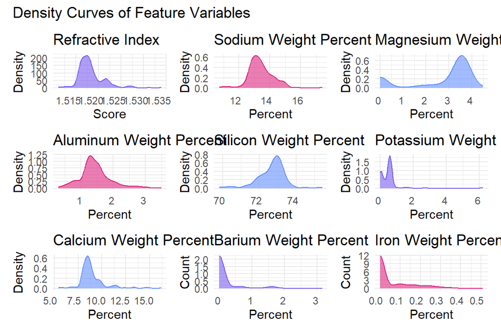

```r
p1 + p2 + p3 + p4 + p5 + p6 + p7 + p8 + p9 +
  plot_layout(ncol = 3) +
  plot_annotation(title = 'Density Curves of Feature Variables')
```

### 2.3 Distribution of Variables by if it was Building Glass

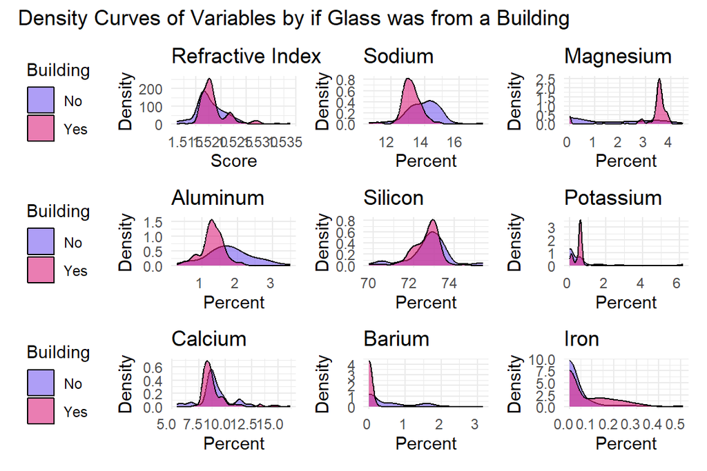

```r
c1<-glass %>%
  ggplot(aes(x = RI, fill=building)) +
  geom_density(alpha=0.6) +
  scale_fill_manual(values=c("#785EF0","#DC267F")) +
  labs(title="Refractive Index", x="Score", y="Density", fill='Building')  +
  theme_minimal() +
   theme(legend.position='left', axis.text.x = element_text(angle=0, vjust=.7, hjust=0.8))



c2<-glass %>%
  ggplot(aes(x = Na, fill=building)) +
  geom_density(alpha=0.6) +
  scale_fill_manual(values=c("#785EF0","#DC267F")) +
  labs(title="Sodium", x="Percent", y="Density")  +
  theme_minimal() +
   theme(legend.position='none', axis.text.x = element_text(angle=0, vjust=.7, hjust=0.8))

c3<-glass %>%
  ggplot(aes(x = Mg, fill=building)) +
  geom_density(alpha=0.6) +
  scale_fill_manual(values=c("#785EF0","#DC267F")) +
  labs(title="Magnesium", x="Percent", y="Density")  +
  theme_minimal() +
   theme(legend.position='none', axis.text.x = element_text(angle=0, vjust=.7, hjust=0.8))

c4<-glass %>%
  ggplot(aes(x = Al, fill=building)) +
  geom_density(alpha=0.6) +
  scale_fill_manual(values=c("#785EF0","#DC267F")) +
  labs(title="Aluminum", x="Percent", y="Density", fill='Building')  +
  theme_minimal() +
   theme(legend.position='left', axis.text.x = element_text(angle=0, vjust=.7, hjust=0.8))



c5<-glass %>%
  ggplot(aes(x = Si, fill=building)) +
  geom_density(alpha=0.6) +
  scale_fill_manual(values=c("#785EF0","#DC267F")) +
  labs(title="Silicon", x="Percent", y="Density")  +
  theme_minimal() +
   theme(legend.position='none', axis.text.x = element_text(angle=0, vjust=.7, hjust=0.8))

c6<-glass %>%
  ggplot(aes(x = K, fill=building)) +
  geom_density(alpha=0.6) +
  scale_fill_manual(values=c("#785EF0","#DC267F")) +
  labs(title="Potassium", x="Percent", y="Density")  +
  theme_minimal() +
   theme(legend.position='none', axis.text.x = element_text(angle=0, vjust=.7, hjust=0.8))


c7<-glass %>%
  ggplot(aes(x = Ca, fill=building)) +
  geom_density(alpha=0.6) +
  scale_fill_manual(values=c("#785EF0","#DC267F")) +
  labs(title="Calcium", x="Percent", y="Density", fill='Building')  +
  theme_minimal() +
   theme(legend.position='left', axis.text.x = element_text(angle=0, vjust=.7, hjust=0.8))



c8<-glass %>%
  ggplot(aes(x = Ba, fill=building)) +
  geom_density(alpha=0.6) +
  scale_fill_manual(values=c("#785EF0","#DC267F")) +
  labs(title="Barium", x="Percent", y="Density")  +
  theme_minimal() +
   theme(legend.position='none', axis.text.x = element_text(angle=0, vjust=.7, hjust=0.8))

c9<-glass %>%
  ggplot(aes(x = Fe, fill=building)) +
  geom_density(alpha=0.6) +
  scale_fill_manual(values=c("#785EF0","#DC267F")) +
  labs(title="Iron", x="Percent", y="Density")  +
  theme_minimal() +
   theme(legend.position='none', axis.text.x = element_text(angle=0, vjust=.7, hjust=0.8))




c1 + c2 + c3 + c4 + c5 + c6 + c7 + c8 + c9 +
  plot_layout(ncol = 3) +
  plot_annotation(title = 'Density Curves of Variables by if Glass was from a Building')
```

For the elements sodium, magnesium, aluminum, potassium, and barium all have distinctive peaks in densities at different points for glass from buildings and not from buildings. This indicates that they could be strong predictors of glass type. For iron, the density distributions are very similar for if the glass is from a building or not with the main difference being that the majority of glass with an iron weight percent greater than 0.1 percent is building glass. For refractive index, calcium and silicon there are no distinctive differences in the density curves between building glass and non-building glass.

## 3 Principal Component Analysis (PCA)

```r
log.glass = log(glass[,-(10:11)]+1)   # drop the categorical variable in the original
                            # data set and transform all numerical to the
                            # log-scale
gl.pca <- prcomp(log.glass, center = TRUE, scale = TRUE)
# summary(ir.pca)[6]   # use the command to explore the possible information
                       # available in the output of the summary.
```

### 3.1 PCA Vectors

```r
kable(round(gl.pca$rotation, 2), caption="Factor loadings of the PCA")
```

Factor loadings of the PCA

|  | PC1 | PC2 | PC3 | PC4 | PC5 | PC6 | PC7 | PC8 | PC9 |
| --- | --- | --- | --- | --- | --- | --- | --- | --- | --- |
| RI | -0.56 | 0.18 | 0.16 | -0.15 | -0.11 | 0.19 | -0.04 | -0.74 | 0.11 |
| Na | 0.21 | 0.37 | -0.37 | -0.45 | 0.23 | -0.44 | -0.24 | -0.24 | -0.34 |
| Mg | -0.05 | -0.56 | -0.19 | -0.35 | 0.12 | 0.28 | 0.44 | -0.12 | -0.47 |
| Al | 0.41 | 0.21 | 0.47 | 0.09 | -0.08 | -0.28 | 0.63 | -0.28 | -0.08 |
| Si | 0.24 | -0.03 | -0.39 | 0.72 | 0.08 | 0.18 | -0.09 | -0.42 | -0.22 |
| K | 0.22 | -0.41 | 0.49 | -0.04 | -0.27 | -0.11 | -0.57 | -0.16 | -0.34 |
| Ca | -0.52 | 0.25 | 0.09 | 0.28 | -0.16 | -0.21 | 0.09 | 0.29 | -0.64 |
| Ba | 0.25 | 0.48 | 0.24 | -0.13 | 0.14 | 0.72 | -0.11 | 0.13 | -0.26 |
| Fe | -0.17 | -0.13 | 0.34 | 0.15 | 0.89 | -0.12 | -0.07 | -0.02 | 0.00 |

### 3.2 Importance of Each Component

```r
kable(summary(gl.pca)$importance, caption="The importance of each principal component")
```

The importance of each principal component

|  | PC1 | PC2 | PC3 | PC4 | PC5 | PC6 | PC7 | PC8 | PC9 |
| --- | --- | --- | --- | --- | --- | --- | --- | --- | --- |
| Standard deviation | 1.595248 | 1.477759 | 1.165573 | 1.082341 | 0.9371736 | 0.6541763 | 0.5838605 | 0.2678638 | 0.1500198 |
| Proportion of Variance | 0.282760 | 0.242640 | 0.150950 | 0.130160 | 0.0975900 | 0.0475500 | 0.0378800 | 0.0079700 | 0.0025000 |
| Cumulative Proportion | 0.282760 | 0.525400 | 0.676350 | 0.806510 | 0.9041000 | 0.9516500 | 0.9895300 | 0.9975000 | 1.0000000 |

Looking at the proportion each PCA contributes to the variance shows the eigth and ninth principal components each contribute less than 1% to the total variance, so we can conclude that they are not contributing a significant amount of information overall. Additionally, it is clear that PC6 and PC7 contribute less than 5% to the overall proportion of variance. However, including PC6 increases the proportion of variance explained from about 90% to 95%, so I will include the first six principal components in my analysis to ensure I lose no more than 5% of the information if all principal components were included.

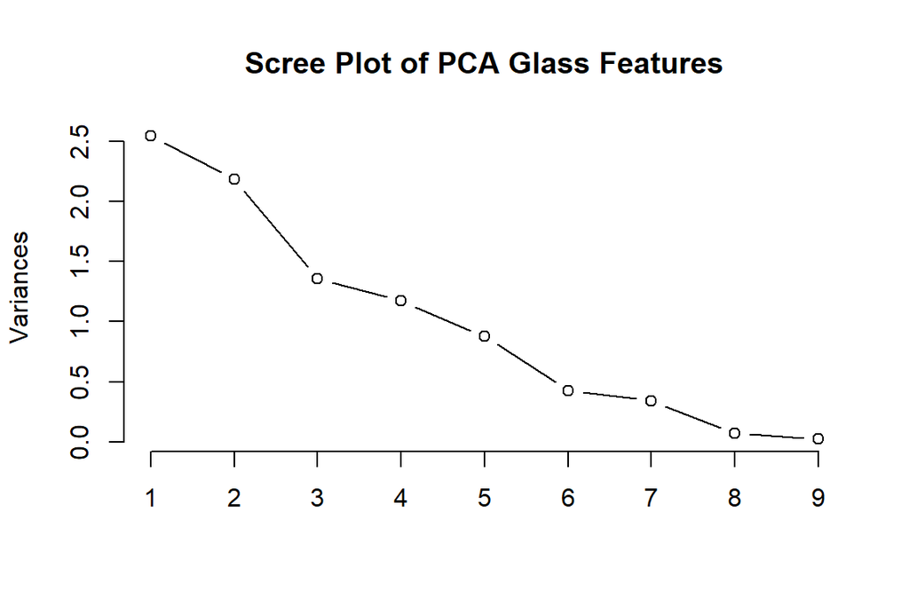

```r
screeplot(gl.pca,
          type = "lines",
          main = "Scree Plot of PCA Glass Features")
```

Looking at the scree plot shows that the difference in variance of the components drops steeply between the first three components before having moderate drops in variance between the third and sixth components. After the sixth component the variance start to level off and are close to zero. The scree plot reaffirms the decision to include up to the sixth principal component into the analysis.

```r
final.glass = glass
final.glass$RI.pc = gl.pca$x[, 1]
final.glass$Mg.pc = gl.pca$x[, 2]
final.glass$K.pc = gl.pca$x[, 3]
final.glass$Si.pc = gl.pca$x[, 4]
final.glass$Fe.pc = gl.pca$x[, 5]
final.glass$Ba.pc = gl.pca$x[, 6]
```

## 4 Clustering Analysis

For the clustering analysis on variables I will apply K-means centroid algorithm between the variables of the refractive index and calcium as they had the highest correlation between any two of the feature variables.

```r
clust.data = glass[, c("RI", "Ca")]
scaled.data = as.data.frame(scale(clust.data)[,1:2])
```

```r
k2 <- kmeans(x = scaled.data,
             centers = 2,
             iter.max = 10,
             nstart = 25,
             algorithm = "Lloyd", #"Hartigan-Wong",
             trace = FALSE)
```

### 4.1 K-Means Clustering

#### 4.1.1 Elbow Point Graph

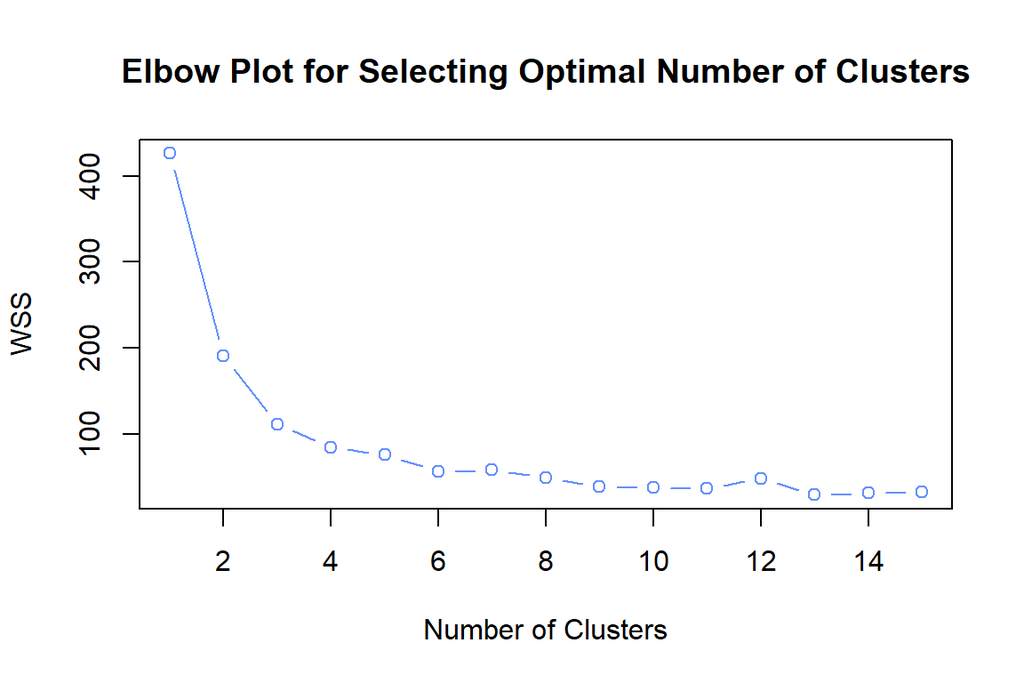

```r
wss = NULL
K = 15
for (i in 1:K){
  wss[i] = kmeans(scaled.data, i, 1 )$tot.withinss
 }
## elbow plot
plot(1:K, wss, type ="b",
          col= "#648FFF",
          xlab="Number of Clusters",
          ylab = "WSS",
          main = "Elbow Plot for Selecting Optimal Number of Clusters")
```

The elbow plot above shows the ideal number of clusters to be about 4 as the the WSS does not have any more consistent decreases as the number of clusters gets to be above 4. In some valuations of the clusters centers, there is an increase in the WSS score going from 4 to 5 clusters, verifying 4 clusters is the ideal number of clusters.

#### 4.1.2 Groups Visualized

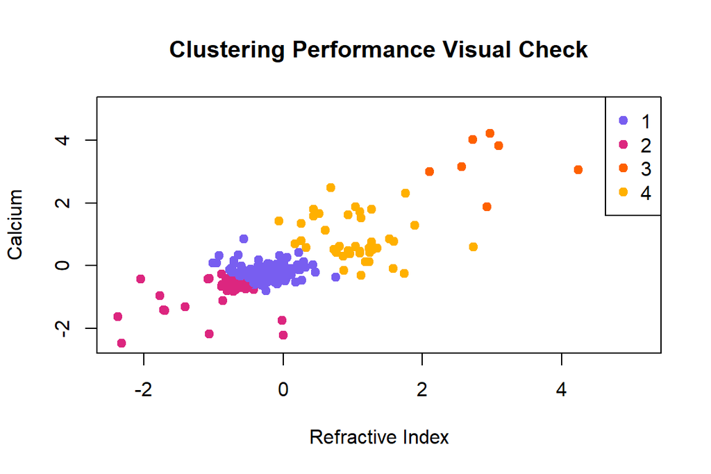

```r
colors<- c("#785EF0","#DC267F", "#FE6100", "#FFB000")
k4 <- kmeans(x = scaled.data,
             centers = 4,
             iter.max = 10,
             nstart = 25,
             algorithm = "Lloyd", # "Hartigan-Wong",
             trace = FALSE)
scaled.data$group = k4$cluster
### Plot the clusters
# Scatter plot
plot(scaled.data$RI, scaled.data$Ca,
     pch = 19,
     col = colors[factor(scaled.data$group)],
     xlab ="Refractive Index",
     ylab = "Calcium",
     main = "Clustering Performance Visual Check")

# Legend
legend("topright",
       legend = levels(factor(scaled.data$group)),
       pch = 19,
       col = colors)
```

## 5 Local Outlier Factor (LOF)

The LOF is a method to identify possible local outliers and can be used as an engineered variable to help improve model prediction accuracy.

### 5.1 LOF of PCAs of Interest

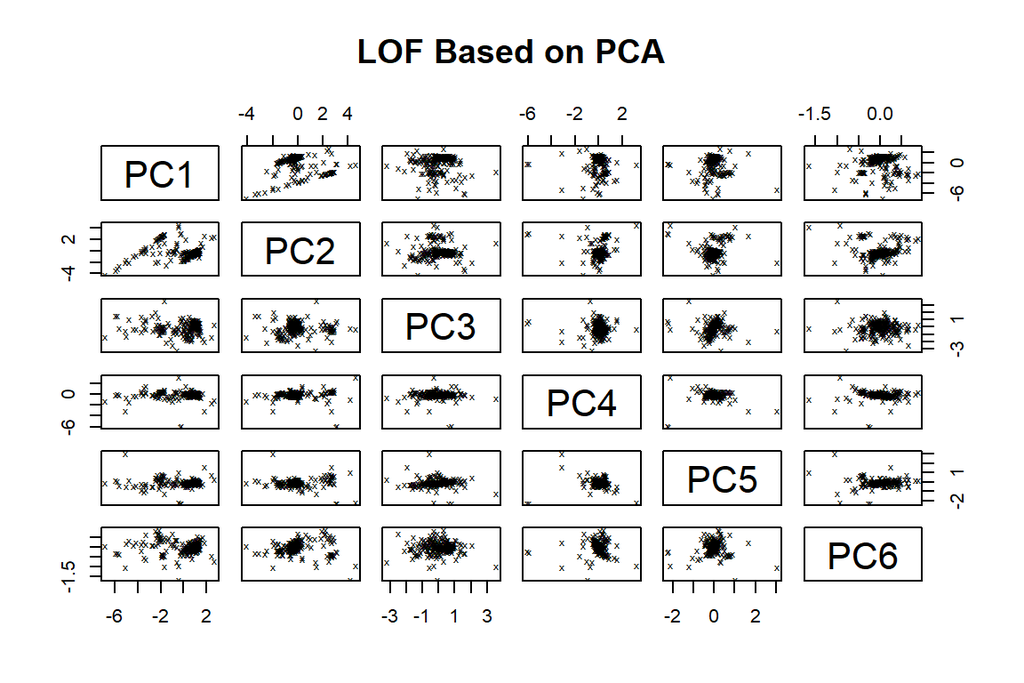

```r
log.glass = glass[,c(1:9)]+1   # drop the categorical variable in the original
                            # data set and transform all numerical to the
                            # log-scale
glass.pca <- prcomp(log.glass, center = TRUE, scale = FALSE)
# use the first two PCs to define a data frame for LOF
pca.glass = data.frame(glass.pca$x[, 1:6])
### Calculate the two LOF scores with the original variables and PCs respectively.
lof.pca <- lof(pca.glass, minPts = 30)  # minPts = k value, number of nearest neighbors
lof.orig <- lof(log.glass, minPts = 30)
## 2D plot of LOF score based on PCs
plot(pca.glass, pch = "x",    # point symbol
     main = "LOF Based on PCA",
     #asp = 1,
     cex = 0.5)                # aspect ratio - ratio of 'y/x'
points(pca.glass,
       cex = (lof.pca-1)*1.5,      # point size according to the LOF score
       pch = 21,
       col = "#785EF0")
text(pca.glass[lof.pca > 1.8,],
     labels = round(lof.pca, 1)[lof.pca > 1.8],
     pos = 1,   # 1, 2, 3 and 4 => below, left , above, and right
     cex = 0.7,
     col = "#DC267F")
```

Looking at the plots of the principal components in the column with PC$ there appear to be outliers on the left side of the graph, with values less than -2 on the x-axis. Additionally, PC1 and PC6 also appear to skew slightly to the left with PC6 having prominent outliers like PC4.

### 5.2 LOF Score Comparison

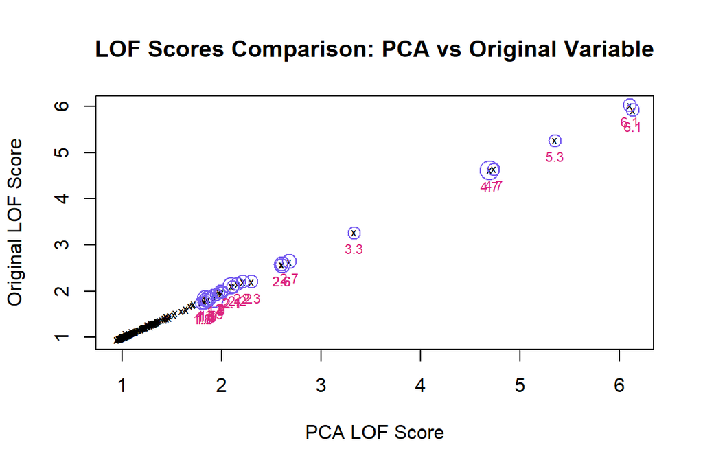

```r
plot(lof.pca, lof.orig, pch ="x",
     main = "LOF Scores Comparison: PCA vs Original Variable",
     xlab = "PCA LOF Score",
     ylab = "Original LOF Score",
     cex = 0.6)
points(lof.pca[lof.pca > 1.8], lof.orig[lof.pca > 1.8],
       pch = 21,
       cex = lof.pca*1.5,
       col = "#785EF0")
text(lof.pca[lof.pca > 1.8], lof.orig[lof.pca > 1.8],
     labels = round(lof.pca, 1)[lof.pca > 1.8],
     pos = 1,   # 1, 2, 3 and 4 => below, left , above, and right
     cex = 0.7,
     col = "#DC267F")
```

The graph of the LOF score comparison shown above shows 6 extreme outliers, 3 of which are really far away from the cluster. Based on the extreme outliers, I imagine that LOF could help improve the model accuracy.

```r
glass <- glass %>%
  mutate(isbuilding=ifelse(building=="Yes", 1, 0))
```

### 5.3 LOF Comparisons

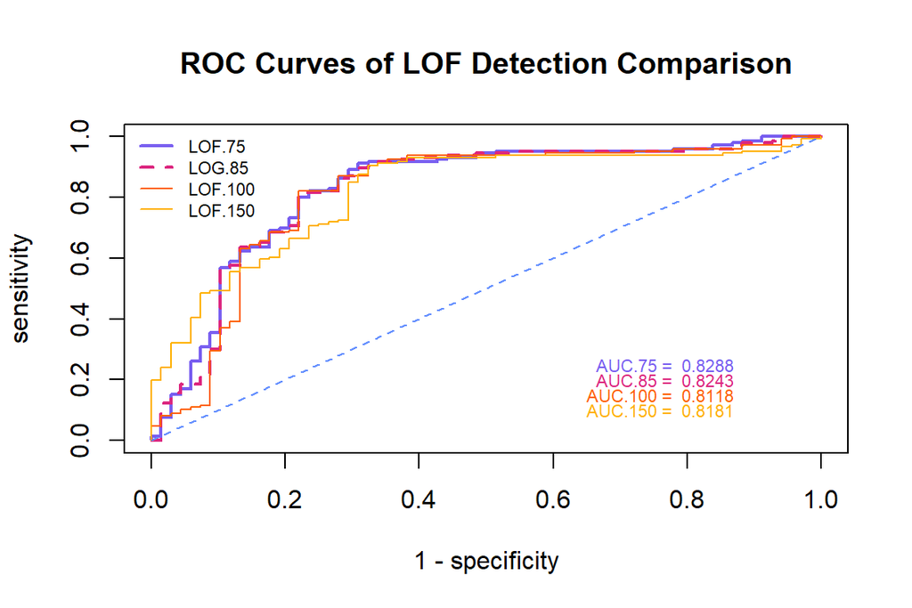

```r
lof.glass.10  <- lof(glass [, 1:9], minPts =75)
lof.glass.50  <- lof(glass [,1:9], minPts = 85)
lof.glass.100  <- lof(glass [, 1:9], minPts = 100)
lof.glass.200  <- lof(glass [, 1:9], minPts = 150)
  ROCobj.lof.10 <- roc(glass$isbuilding, lof.glass.10, direction = ">")
  ROCobj.lof.50 <- roc(glass$isbuilding, lof.glass.50, direction = ">")
  ROCobj.lof.100 <- roc(glass$isbuilding, lof.glass.100, direction = ">")
  ROCobj.lof.200 <- roc(glass$isbuilding, lof.glass.200, direction = ">")
  ##
  sen.LOF.10 = ROCobj.lof.10$sensitivities
  fnr.LOF.10 = 1 - ROCobj.lof.10$specificities
  ##
  sen.LOF.50 = ROCobj.lof.50$sensitivities
  fnr.LOF.50 = 1 - ROCobj.lof.50$specificities
  ##
  sen.LOF.100 = ROCobj.lof.100$sensitivities
  fnr.LOF.100 = 1 - ROCobj.lof.100$specificities
  ##
  sen.LOF.200 = ROCobj.lof.200$sensitivities
  fnr.LOF.200 = 1 - ROCobj.lof.200$specificities
par(type="s")
colors = c("#785EF0","#DC267F", "#FE6100", "#FFB000")
plot(fnr.LOF.10, sen.LOF.10, type = "l", lwd = 2, col = colors[1],
     xlim = c(0,1),
     ylim = c(0,1),
     xlab = "1 - specificity",
     ylab = "sensitivity",
     main = "ROC Curves of LOF Detection Comparison")
lines(fnr.LOF.50, sen.LOF.50, lwd = 2, lty = 2, col = colors[2])
lines(fnr.LOF.100, sen.LOF.100, lwd = 1, col = colors[3])
lines(fnr.LOF.200, sen.LOF.200, lwd = 1, col = colors[4])

segments(0,0,1,1, lwd =1, col = "#648FFF", lty = 2)
legend("topleft", c("LOF.75", "LOG.85", "LOF.100", "LOF.150"),
       col=colors, lwd=c(2,2,1,1,1),
       lty=c(1,2,1,1,2), bty = "n", cex = 0.7)

##
AUC.10 = ROCobj.lof.10$auc
AUC.50 = ROCobj.lof.50$auc
AUC.100 = ROCobj.lof.100$auc
AUC.200 = ROCobj.lof.200$auc
text(0.87, 0.25, paste("AUC.75 = ", round(AUC.10,4)), col=colors[1], cex = 0.7, adj = 1)
text(0.87, 0.20, paste("AUC.85 = ", round(AUC.50,4)), col=colors[2], cex = 0.7, adj = 1)
text(0.87, 0.15, paste("AUC.100 = ", round(AUC.100,4)), col=colors[3], cex = 0.7, adj = 1)
text(0.87, 0.10, paste("AUC.150 = ", round(AUC.200,4)), col=colors[4], cex = 0.7, adj = 1)
```

```r
final.glass$kmeans = k4$cluster
final.glass$lof= lof.glass.10
```

```r
glass<-glass %>%
  select(!c(building, Type))
```